# STAT340 HW0: R Review

Keith Levin

September 2022

## Instructions

Update the “author” and “date” fields in the header and complete the exercises below. Knit the document, and submit **both the HTML and RMD** files to Canvas.

**Due date:** Thursday, September 15 2022 at 11:59pm

This homework is designed to give you a quick review of some of the basics of R that you learned in STAT240.

## Problem 1: Plotting review

Let’s quickly recap some of the basic plotting and data exploration tools available in R. You are free to use either the built-in R plotting tools or `ggplot2` for these problems; whichever you are more comfortable with.

### 1(a): creating a histogram

The following block of code generates 200 standard normal random variables and stores them in a vector called `normals`. Use either the built-in R plotting tools or `ggplot2` to create a histogram of these points. Title your plot “Histogram of normals”. There is no need to save this plot in an image file; simply display it in-line in the R markdown file.

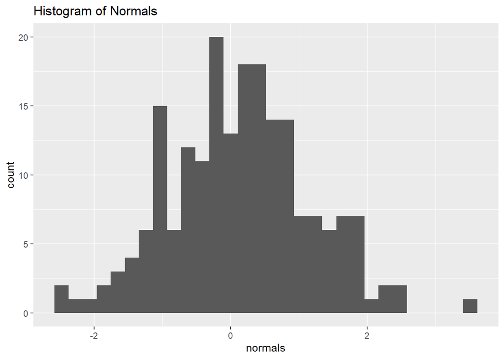

```r
normals <- rnorm( 200 ); # Generate 200 standard normals. See ?rnorm for details

# TODO: plotting code goes here.
ggplot() +
  aes(normals) +
  geom_histogram() +
  ggtitle("Histogram of Normals")
```

### 1(b): creating a scatter plot

Download the file `nile.csv` from the course webpage ([available here](https://pages.stat.wisc.edu/~kdlevin/teaching/Fall2022/STAT340/hw/hw00/nile.csv) )) or from Canvas. This comma-separated value (CSV) file contains data describing the annual flow of the Nile river from 1871 to 1970 (adapted from a built-in data set in R; see `?Nile`). The file has two columns, titled `Year` and `Flow`. Each row corresponds to a year, with the first column giving the year and the second column given the flow for that year in $10^8$ cubic meters (10 million cubic meters).

Read the file into a dataframe (you may use either the R built-in functions like `read.csv` or use tidyverse tools).

```r
nile = read_csv("nile.csv")
head(nile)
```

```
## # A tibble: 6 x 2
##    Year  Flow
##   <dbl> <dbl>
## 1  1871  1120
## 2  1872  1160
## 3  1873   963
## 4  1874  1210
## 5  1875  1160
## 6  1876  1160
```

Create a scatter-plot showing the year on the x-axis and the flow (in 10 million cubic meters) on the y-axis. Give your plot a sensible title and be sure to label the x- and y-axes. There is no need to save this plot in a figure; simply display it in-line in the R markdown file.

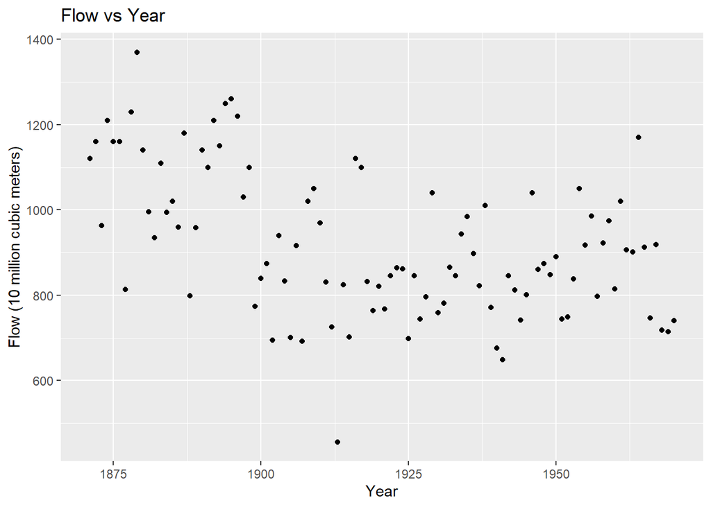

```r
# TODO: plotting code goes here.
ggplot(nile, aes(x = Year, y = Flow)) +
  geom_point() +
  ggtitle("Flow vs Year") +
  ylab("Flow (10 million cubic meters)")
```

Do you see any trends in the data over time or anything else interesting? There are no strictly right or wrong answers– just say enough to prove that you looked at the plot!

The graph follows a trend that as the year increases, the flow decreases.

## Problem 2: Defining simple functions in R.

This is not a programming course, but you do need a certain amount of programming to do data science. Toward that end, let’s refresh our memory regarding function definition in R.

### 2(a): repeater

Write a function `print_twice` that takes a single argument `x` and prints that argument twice, once per line. You may assume that the argument `x` is an object that can sensibly be printed (i.e., we are not going to do anything tricky like trying to call `print_twice` on something that’s going to cause a weird error).

**Reminder:** to print something in R, use the `cat()` function. *Do not* use `print()` to print in R (I know, it’s confusing!).

```r
print_twice <- function( x ) {
  # TODO: code goes here.
  cat(x, "\n")
  cat(x, "\n")
}
```

### 2(b): repeater, repeated

Let’s generalize our `print_twice` function. Define a function `repeat_n` that takes two arguments, `x` and `n`, where `x` is arbitrary (but again, something that can be printed using `cat(x)`) and `n` is a non-negative integer. `repeat_n(x,n)` should print `x` `n` times, once per line.

**Reminder:** use `cat(x)` to print `x`.

**Note:** think carefully about what should happen when `n` is zero!

**Hint:** use a for-loop or while-loop. See, e.g., (https://r4ds.had.co.nz/iteration.html)[here].

You may assume that `x` is printable (i.e., `cat(x)` will not cause an error) and that `n` is a non-negative integer.

```r
repeat_n <- function( x, n ) {
  #TODO: code goes here.
  if (n != 0) {
    for (i in 1:n) {
      cat(x, "\n")
    }
  }
}
```

### 2(c): enumerating the triangular numbers

For $n=0,1,2,\dots$, the $n$-th [triangular number](https://en.wikipedia.org/wiki/Triangular_number) is given by
$$T_n = n(n+1)/2.$$
Define a function `triangular` that takes a single argument `n` and returns the `n`-th triangular number. You may assume that `n` is a non-negative integer.

```r
triangular <- function( n ) {
  # TODO: code goes here.
  return(n * (n + 1) / 2)
}
```

### 2(d): summarizing data

Define a function `my_summary` that takes a vector `x` as its only argument and returns a length-4 vector as its output whose

- first entry is the mean of `x`,
- second entry is the standard deviation of `x` (using either $n$ or $n-1$ in the denominator; your choice)
- third entry is the minimum entry of `x`
- fourth entry is the maximum entry of `x`.

```r
# TODO: function definition goes here.
my_summary = function(x) {
  mu = mean(x)
  stdd = sd(x)
  mini = min(x)
  maxi = max(x)
  return(c(mu, stdd, mini, maxi))
}
```

## Problem 3: loading and exploring data

Download the CSV file `SFO-2018.csv` from Canvas or [from the course webpage](https://pages.stat.wisc.edu/~kdlevin/teaching/Fall2022/STAT340/hw/hw00/SFO-2018.csv). This file should be at least vaguely familiar to you from STAT240– [see here](https://bookdown.org/bret_larget/stat-240-case-studies/airport-waiting-times.html) for a refresher. It describes data concerning waiting times at Customs and Border Patrol (CBP) at San Francisco International airport (SFO) in 2018. Read the summary at the link for a refresher.

### 3(a): loading the data

Read the CSV file into a data frame called `sfo`. You may use either the built-in R functions for reading files or use tidyverse tools.

How many data points are in the file (i.e., how many rows in the data frame)?

```r
# TODO: code goes here.
sfo = read_csv("SFO-2018.csv")
nrow(sfo)
```

```
## [1] 11097
```

How many different Terminals are attested in the data (i.e., how many distinct values are in the `Terminal` column)?

```r
#TODO: code goes here.
sfo %>%
  group_by(Terminal) %>%
  summarize()
```

```
## # A tibble: 2 x 1
##   Terminal
##   <chr>
## 1 Terminal A
## 2 Terminal G
```

There are two terminals.

### 3(b): how many flights?

How many international flights were handled at SFO in total (i.e., over all the terminals combined) on April 1st, 2018?

You may use either tidyverse tools or built-in R functions to answer this question.

```r
#TODO: code goes here.
april_1st = sfo %>%
  filter(Date == "4/1/2018")

sum(april_1st$Flights)
```

```
## [1] 77
```

### 3(c): how bad could it be?

What was the longest average wait time experienced by US citizens in the data set (i.e., the largest value in the `U.S._Citizen_Average_Wait_Time` column), and when did it occur (day and hour)?

```r
# TODO: code goes here.
sfo %>%
  select(Date, Hour, US_Citizen_Average_Wait_Time) %>%
  arrange(desc(US_Citizen_Average_Wait_Time)) %>%
  head(1)
```

```
## # A tibble: 1 x 3
##   Date      Hour        US_Citizen_Average_Wait_Time
##   <chr>     <chr>                              <dbl>
## 1 1/10/2018 0400 - 0500                           85
```

What about for the longest average wait time experienced by non-US citizens (the `Non_U.S._Citizen_Average_Wait_Time` column)?

```r
# TODO: code goes here.
sfo %>%
  select(Date, Hour, Non_US_Citizen_Average_Wait_Time) %>%
  arrange(desc(Non_US_Citizen_Average_Wait_Time)) %>%
  head(1)
```

```
## # A tibble: 1 x 3
##   Date     Hour        Non_US_Citizen_Average_Wait_Time
##   <chr>    <chr>                                  <dbl>
## 1 7/6/2018 1500 - 1600                              121
```